# Edge cutoff

Jason T. Serviss

2018-12-06

```r
#PACKAGES
library(CIMseq)
library(sp.scRNAseqData)
library(tidyverse)
library(printr)
```

One question that has repeatedly arisen is where to set the edge cutoff. The edge cutoff, in this case, referes to the minimum value of a fraction that is needed to constitute an edge. Multiple factors are valid to consider when determining this, one of which is the RNA contribution from the individual cell types included in a multiplet. In the case that the multiplet is a doublet and the RNA contribution is equal from both cells, we would expect the fractions for the deconvolution to be 0.5 and 0.5. Although, RNA contribution is typically not equal from both cells. In the case that the multiplet is a doublet and one cell contributes less RNA than the other cell, we expect that the cell contributing less RNA than the other cell will get a lower fraction.

In order ot get a understanding of what the range of “valid” fractions are for any set of cells, we can use the following steps:

1. Use the ERCC reads to calculate the RNA content from all of the individual singlets.
2. Make all possible multiplet conbinations based on the cell types included in the dataset. For example, if there are 3 cell types (A, B, and C) the possible duplicate multiplets are A-A, A-B, A-C, B-B, B-C, and C-C.
3. Randomly pick singlets to make the multiplets in 2). Calculate the fraction of RNA contribution from each.
4. Repeat 3) n times to get a good representation of the distribution for that specific combination.

### Sorted Multiplet Dataset

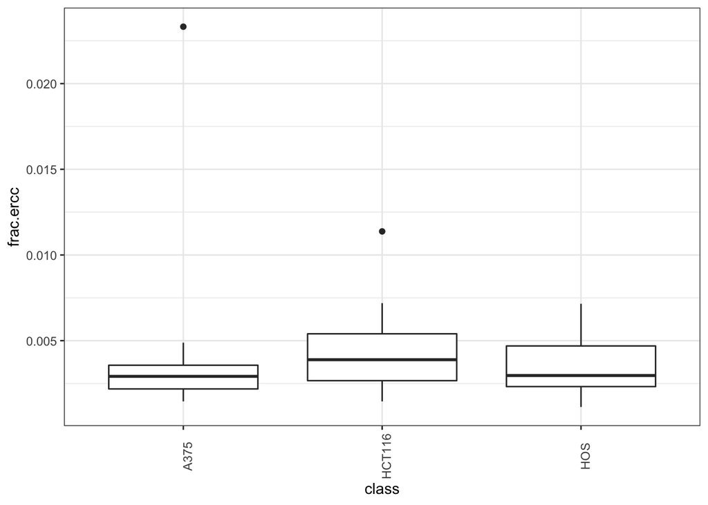

```r
#DATA
load('../SCM.analysis/data/CIMseqData.rda')
load('../SCM.analysis/data/sObj.rda')

#Rename classes
renameClasses <- function(class) {
  case_when(
    class == "0" ~ "A375",
    class == "1" ~ "HCT116",
    class == "2" ~ "HOS",
    TRUE ~ "error"
  )
}

getData(cObjSng, "classification") <- renameClasses(getData(cObjSng, "classification"))
fractions <- getData(sObj, "fractions")
colnames(fractions) <- renameClasses(colnames(fractions))
sObj@fractions <- fractions

#Read ercc info
ercc.info <- read_csv2('ercc.conc.csv')
ercc.info <- mutate(ercc.info, bp.ul = ((amol.ul * Length)* 10e-18)/6.02214076*10e23)
ercc.info <- mutate(ercc.info, bp.per.well = (bp.ul/(24 * 10e6))*4)
ercc.sum <- sum(pull(ercc.info, bp.per.well))

#calculate RNA abundance
counts <- getData(cObjSng, "counts")
counts.ercc <- getData(cObjSng, "counts.ercc")
cs.counts <- matrixStats::colSums2(counts)
cs.counts.ercc <- matrixStats::colSums2(counts.ercc)
data <- tibble(
  sample = colnames(counts),
  frac.ercc = cs.counts.ercc / (cs.counts + cs.counts.ercc),
  frac.counts = cs.counts / (cs.counts + cs.counts.ercc),
  bp = (1 / frac.ercc) * ercc.sum
) %>%
  inner_join(tibble(
    sample = colnames(getData(cObjSng, "counts")),
    class = getData(cObjSng, "classification")
  ))

#Plot ercc fraction per class
data %>%
  ggplot() +
  geom_boxplot(aes(class, frac.ercc)) +
  theme(axis.text.x = element_text(angle = 90))
```

```r
#calculate fraction of contribution for all possible combinations
u.classes <- unique(getData(cObjSng, "classification"))
dups <- expand.grid(u.classes, u.classes, stringsAsFactors = FALSE)
trips <- expand.grid(u.classes, u.classes, u.classes, stringsAsFactors = FALSE)
quads <- expand.grid(u.classes, u.classes, u.classes, u.classes, stringsAsFactors = FALSE)
quints <- expand.grid(u.classes, u.classes, u.classes, u.classes, u.classes, stringsAsFactors = FALSE)

#remove duplicate multiplets
dups <- map_dfr(1:nrow(dups), ~data.frame(unname(sort(dups[.x, ]))))
trips <- map_dfr(1:nrow(trips), ~data.frame(unname(sort(trips[.x, ]))))
quads <- map_dfr(1:nrow(quads), ~data.frame(unname(sort(quads[.x, ]))))
quints <- map_dfr(1:nrow(quints), ~data.frame(unname(sort(quints[.x, ]))))

dups <- dups[!duplicated(dups), ]
trips <- trips[!duplicated(trips), ]
quads <- quads[!duplicated(quads), ]
quints <- quints[!duplicated(quints), ]

#assign additional info and reformat

dups$id <- 1:nrow(dups)
trips$id <- 1:nrow(trips)
quads$id <- 1:nrow(quads)
quints$id <- 1:nrow(quints)

dups$type <- "duplicates"
trips$type <- "triplicates"
quads$type <- "quadruplicates"
quints$type <- "quintuplets"

dups <- nest(dups, -(id:type))
trips <- nest(trips, -(id:type))
quads <- nest(quads, -(id:type))
qunits <- nest(quints, -(id:type))
combos <- bind_rows(dups, trips, quads, qunits)
pic.vec <- data$bp
names(pic.vec) <- data$class

#calculate contribution
reps <- 500
out <- combos %>%
  as_tibble() %>%
  mutate(frac = map(data, function(c) {
    idx <- map_dfc(c, ~sample(which(names(pic.vec) == .x), reps, replace = TRUE))
    map_dbl(1:nrow(idx), function(i) {
      curr.idxs <- as.numeric(idx[i, ])
      min(map_dbl(curr.idxs, function(i) pic.vec[i] / sum(pic.vec[curr.idxs])))
    })
  })) %>%
  mutate(data = map_chr(data, ~paste(.x, collapse = "-"))) %>%
  unnest()
```

Plot the fraction of contributions per cell type and multiplet type. Y-axis logged.

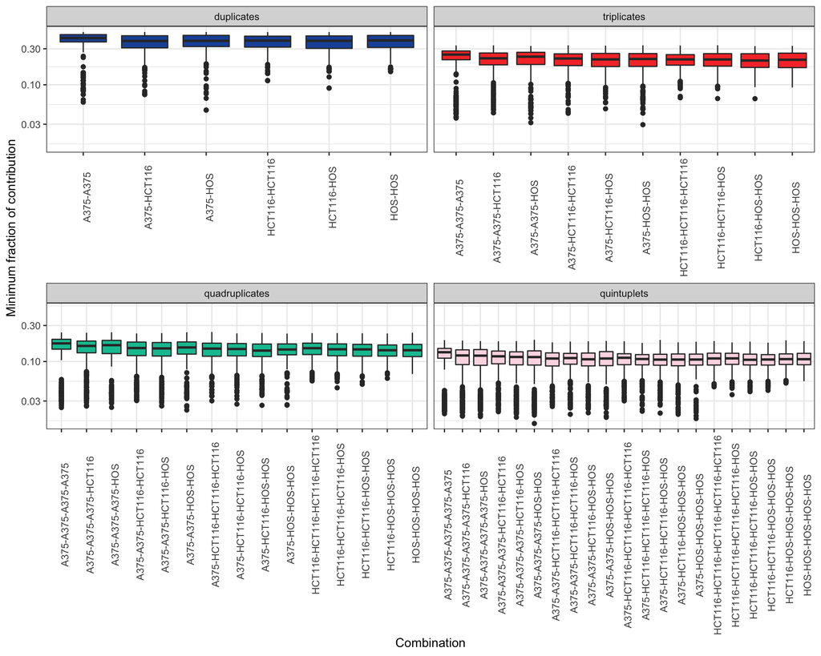

```r
out %>%
  mutate(type = parse_factor(type, levels = c(
    "duplicates", "triplicates", "quadruplicates", "quintuplets"
  ))) %>%
  ggplot() +
  geom_boxplot(aes(data, frac, fill = type)) +
  facet_wrap(~type, scales = "free_x") +
  scale_y_log10() +
  scale_fill_manual(values = col40()) +
  labs(y = "Minimum fraction of contribution", x = "Combination") +
  guides(fill = FALSE) +
  theme(axis.text.x = element_text(angle = 90))
```

Show the lowest fraction based per multiplet type.

```r
out %>%
  group_by(type) %>%
  summarize(m = min(frac)) %>%
  as.data.frame()
```

| type | m |
| --- | --- |
| duplicates | 0.0462454 |
| quadruplicates | 0.0227662 |
| quintuplets | 0.0151054 |
| triplicates | 0.0295982 |

The results indicate what we would expect and also, that we could more easily estimate the fraction range. For example, estimate the fraction range in a triplicate, we would just need to estimate the fraction of contributions in a triplet with the cell type of least contribution once together with 2 of the cell type with the highest contribution.

Instead of using the average RNA contribution per cell type, we can better estimate the range by selecting the individual cell with the least contribution and vice versa.

```r
estimateLowestFraction <- function(singlets, multiplets, cellNumbers = 2:5) {
  ercc <- estimateCells(singlets, multiplets) %>%
    filter(sampleType == "Singlet") %>%
    mutate(RNAcont = 1 / frac.ercc)

  min <- pull(ercc, RNAcont)[which(pull(ercc, RNAcont) == min(pull(ercc, RNAcont)))]
  max <- pull(ercc, RNAcont)[which(pull(ercc, RNAcont) == max(pull(ercc, RNAcont)))]
  tibble(cellsInMul = cellNumbers) %>%
    mutate(min = map_dbl(cellsInMul, function(t) {
      min / sum(c(min, rep(max, t)))
    })) %>%
    mutate(max = map_dbl(cellsInMul, function(t) {
      max / sum(max, rep(min, t))
    }))
}

estimateMedianFraction <- function(singlets, multiplets, cellNumbers = 2:5) {
  medians <- estimateCells(singlets, multiplets) %>%
    filter(sampleType == "Singlet") %>%
    mutate(RNAcont = 1 / frac.ercc) %>%
    full_join(tibble(
      sampleName = colnames(getData(singlets, "counts")),
      class = getData(singlets, "classification")
    )) %>%
    group_by(class) %>%
    summarize(median = median(RNAcont))

  min <- pull(medians, median)[which(pull(medians, median) == min(pull(medians, median)))]
  max <- pull(medians, median)[which(pull(medians, median) == max(pull(medians, median)))]
  tibble(cellsInMul = cellNumbers) %>%
    mutate(min = map_dbl(cellsInMul, function(t) {
      min / sum(c(min, rep(max, t)))
    })) %>%
    mutate(max = map_dbl(cellsInMul, function(t) {
      max / sum(max, rep(min, t))
    }))
}

estimateLowestFraction(cObjSng, cObjMul)
```

| cellsInMul | min | max |
| --- | --- | --- |
| 2 | 0.0236700 | 0.9998617 |
| 3 | 0.0159055 | 0.9997926 |
| 4 | 0.0119768 | 0.9997235 |
| 5 | 0.0096044 | 0.9996543 |

Due to the fact that we know the contents of the multiplets in this dataset, we can evaluate edge cutoffs in another way. Below we calculate:

1. n detected edges / n expected edges
2. false positive rate
3. accuracy

for multiple edge cutoffs.

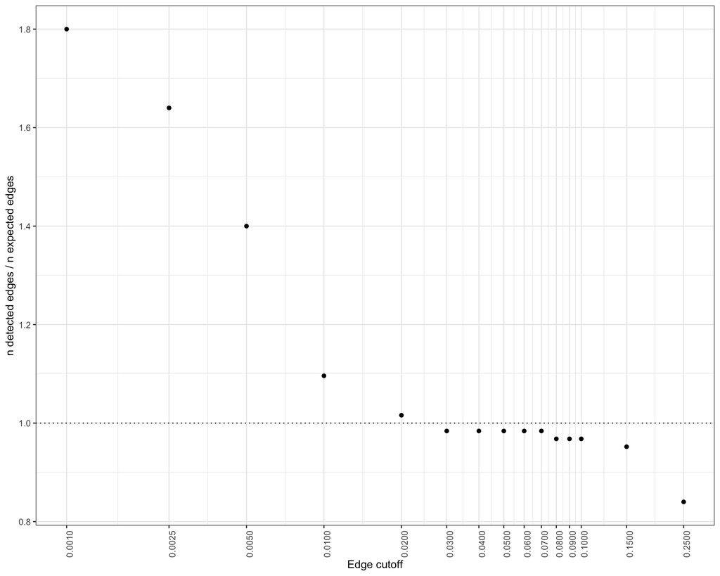

```r
cuts <- c(0.001, 0.0025, 0.005, seq(0.01, 0.1, 0.01), 0.15, 0.25)
known <- sp.scRNAseqTesting::setupPlate(SCM.Meta)
score <- map_dbl(cuts, function(c) {
  res <- sp.scRNAseqTesting::checkResults(sObj, known, cObjSng, c)
  d <- res %>%
    mutate(detected = map(data.detected, pull, connections)) %>%
    select(detected) %>%
    unnest() %>%
    count(detected)

  e <- res %>%
    mutate(expected = map(data.expected, pull, connections)) %>%
    select(expected) %>%
    unnest() %>%
    count(expected)

  d <- full_join(d, e, by = c("detected" = "expected")) %>%
    rename(connection = detected, n.expected.edges = n.y, n.detected.edges = n.x) %>%
    replace_na(list(n.expected.edges = 0, n.detected.edges = 0)) %>%
    select(connection, n.expected.edges, n.detected.edges)

  sum(pull(d, n.detected.edges)) / sum(pull(d, n.expected.edges))
})

tibble(
  edge.cutoff = cuts,
  score = score
) %>%
  ggplot() +
  geom_point(aes(edge.cutoff, score)) +
  geom_hline(yintercept = 1, lty = 3) +
  scale_x_log10(breaks = cuts) +
  theme(axis.text.x = element_text(angle = 90)) +
  labs(x = "Edge cutoff", y = "n detected edges / n expected edges")
```

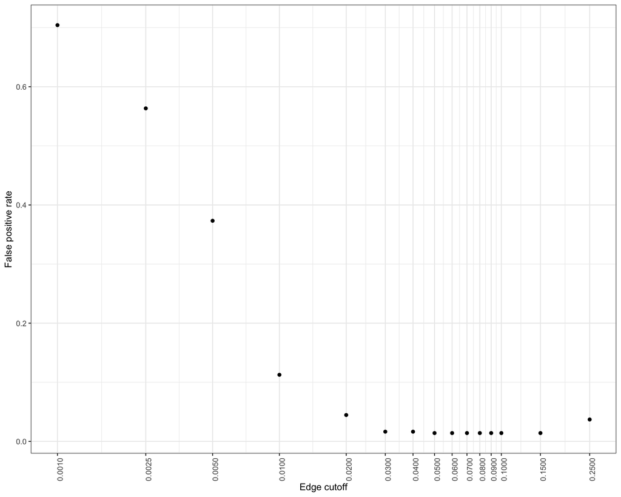

```r
fpr <- map_dbl(cuts, function(c) {
  res <- sp.scRNAseqTesting::checkResults(sObj, known, cObjSng, c) %>%
    mutate(FPR = fp / (fp + tn))
  fpr <- pull(res, FPR)
  mean(fpr[!is.nan(fpr)])
})

tibble(
  edge.cutoff = cuts,
  FPR = fpr
) %>%
  ggplot() +
  geom_point(aes(edge.cutoff, FPR)) +
  scale_x_log10(breaks = cuts) +
  theme(axis.text.x = element_text(angle = 90)) +
  labs(x = "Edge cutoff", y = "False positive rate")
```

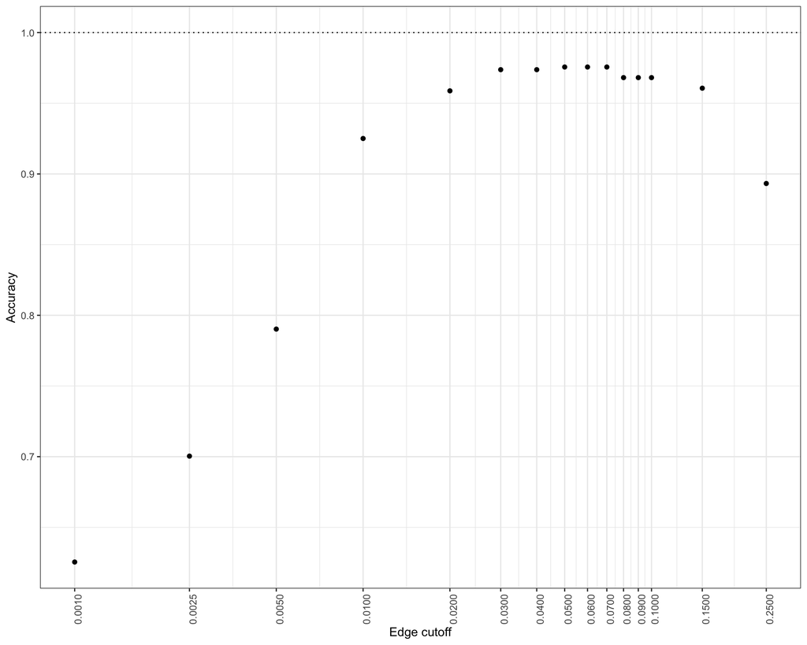

```r
acc <- map_dbl(cuts, function(c) {
  res <- sp.scRNAseqTesting::checkResults(sObj, known, cObjSng, c)
  mean(pull(res, ACC))
})

tibble(
  edge.cutoff = cuts,
  acc = acc
) %>%
  ggplot() +
  geom_point(aes(edge.cutoff, acc)) +
  geom_hline(yintercept = 1, lty = 3) +
  scale_x_log10(breaks = cuts) +
  theme(axis.text.x = element_text(angle = 90)) +
  labs(x = "Edge cutoff", y = "Accuracy")
```

### Mouse Small Intestine Dataset

In order to get an understanding of the fraction distributions in a more complex dataset, below we utilize the mouse small intestine dataset to reperform the above analysis.

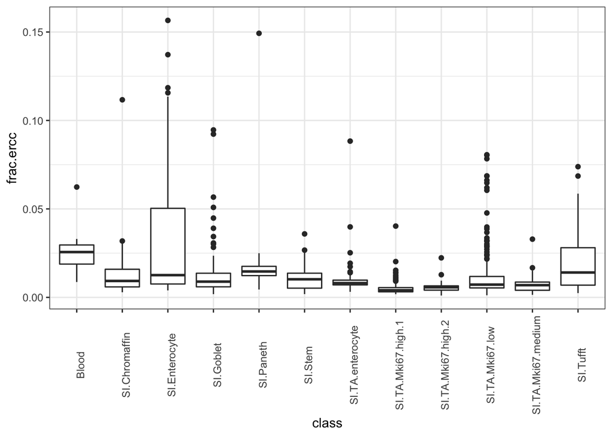

```r
load('../MGA.analysis_SI/data/CIMseqData_181126.rda')
load('../MGA.analysis_SI/data/sObj_181126.rda')

renameClasses <- function(class) {
  case_when(
    class == "0" ~ "SI.TA.Mki67.medium",
    class == "1" ~ "SI.TA.Mki67.low",
    class == "2" ~ "SI.Stem",
    class == "3" ~ "SI.Goblet",
    class == "4" ~ "SI.TA.enterocyte",
    class == "5" ~ "SI.TA.Mki67.high.1",
    class == "6" ~ "SI.Enterocyte",
    class == "7" ~ "SI.TA.Mki67.high.2",
    class == "8" ~ "SI.Paneth",
    class == "9" ~ "SI.Tufft",
    class == "10" ~ "SI.Chromaffin",
    class == "11" ~ "Blood",
    TRUE ~ "error"
  )
}
getData(cObjSng, "classification") <- renameClasses(getData(cObjSng, "classification"))
fractions <- getData(sObj, "fractions")
colnames(fractions) <- renameClasses(colnames(fractions))
sObj@fractions <- fractions

counts <- getData(cObjSng, "counts")
counts.ercc <- getData(cObjSng, "counts.ercc")
cs.counts <- matrixStats::colSums2(counts)
cs.counts.ercc <- matrixStats::colSums2(counts.ercc)
data <- tibble(
  sample = colnames(counts),
  frac.ercc = cs.counts.ercc / (cs.counts + cs.counts.ercc),
  frac.counts = cs.counts / (cs.counts + cs.counts.ercc),
  bp = (1 / frac.ercc) * ercc.sum
) %>%
  inner_join(tibble(
    sample = colnames(getData(cObjSng, "counts")),
    class = getData(cObjSng, "classification")
  ))


data %>%
  ggplot() +
  geom_boxplot(aes(class, frac.ercc)) +
  theme(axis.text.x = element_text(angle = 90))
```

```r
u.classes <- unique(getData(cObjSng, "classification"))
dups <- expand.grid(u.classes, u.classes, stringsAsFactors = FALSE)
trips <- expand.grid(u.classes, u.classes, u.classes, stringsAsFactors = FALSE)
quads <- expand.grid(u.classes, u.classes, u.classes, u.classes, stringsAsFactors = FALSE)

#remove duplicate multiplets
dups <- map_dfr(1:nrow(dups), ~data.frame(unname(sort(dups[.x, ]))))
trips <- map_dfr(1:nrow(trips), ~data.frame(unname(sort(trips[.x, ]))))
quads <- map_dfr(1:nrow(quads), ~data.frame(unname(sort(quads[.x, ]))))

dups <- dups[!duplicated(dups), ]
trips <- trips[!duplicated(trips), ]
quads <- quads[!duplicated(quads), ]

#add additional info and reformat
dups$id <- 1:nrow(dups)
trips$id <- 1:nrow(trips)
quads$id <- 1:nrow(quads)

dups$type <- "duplicates"
trips$type <- "triplicates"
quads$type <- "quadruplicates"

dups <- nest(dups, -(id:type))
trips <- nest(trips, -(id:type))
quads <- nest(quads, -(id:type))
combos <- bind_rows(dups, trips, quads)
pic.vec <- data$bp
names(pic.vec) <- data$class

#calculate fraction of contribution
reps <- 100
out <- combos %>%
  as_tibble() %>%
  mutate(frac = map(data, function(c) {
    idx <- map_dfc(c, ~sample(which(names(pic.vec) == .x), reps, replace = TRUE))
    map_dbl(1:nrow(idx), function(i) {
      curr.idxs <- as.numeric(idx[i, ])
      min(map_dbl(curr.idxs, function(i) pic.vec[i] / sum(pic.vec[curr.idxs])))
    })
  })) %>%
  mutate(data = map_chr(data, ~paste(.x, collapse = "-"))) %>%
  unnest()
```

Show the lowest fraction based per multiplet type.

```r
out %>%
  group_by(type) %>%
  summarize(m = min(frac)) %>%
  as.data.frame()
```

| type | m |
| --- | --- |
| duplicates | 0.0137955 |
| quadruplicates | 0.0048195 |
| triplicates | 0.0057396 |

Plot the results.

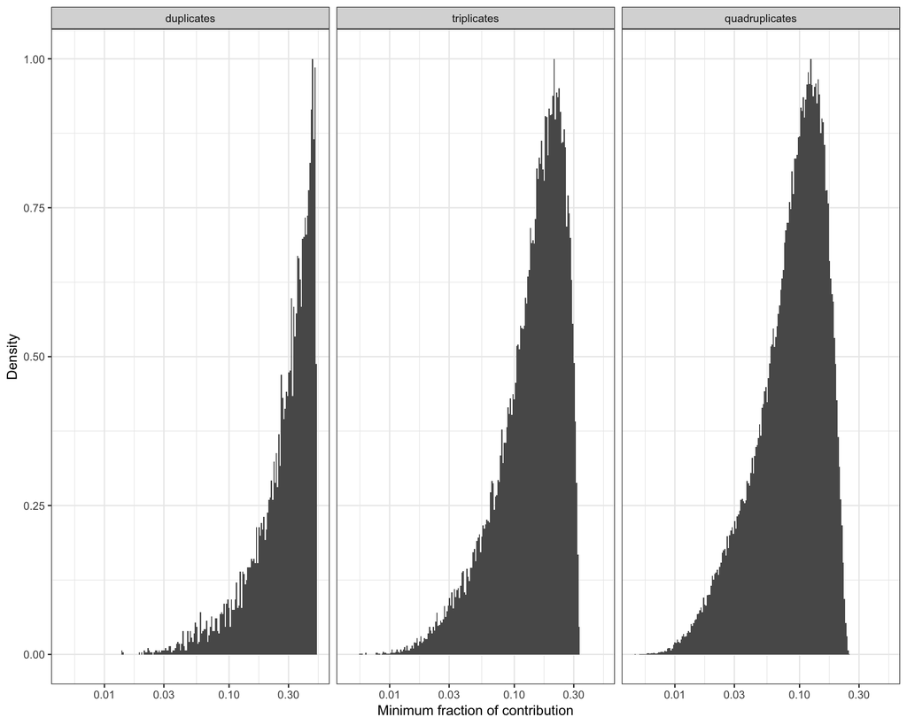

```r
out %>%
  mutate(type = parse_factor(type, levels = c(
    "duplicates", "triplicates", "quadruplicates"
  ))) %>%
  ggplot() +
  geom_histogram(aes(frac, stat(ndensity)), binwidth = 0.01) +
  facet_wrap(~type) +
  scale_x_log10() +
  labs(y = "Density", x = "Minimum fraction of contribution")
```